**Netflix Project**

Netflix is one of the most popular media and video streaming platforms. They have over 10000 movies or tv shows available on their platform, as of mid- 2021, they have over 222M Subscribers globally

# **Attribute Information**

**Show_id:** Unique ID for every Movie / Tv Show  
**Type:** Identifier - A Movie or TV Show  
**Title:** Title of the Movie / Tv Show  
**Director:** Director of the Movie  
**Cast:** Actors involved in the movie/show  
**Country:** Country where the movie/show was produced  
**Date_added:** Date it was added on Netflix  
**Release_year:** Actual Release year of the movie/show  
**Rating:** TV Rating of the movie/show  
**Duration:** Total Duration - in minutes or number of seasons  
**Listed_in:** Genre  
**Description:** The summary description

# Objective

Analyze the data and generate insights that could help Netflix in deciding which type of shows/movies to produce and how they can grow the business in different countries?

## Questions are Analized

**1.** How has the number of movies released per year changed over the last 20-30 years  
**2.** Comparison of tv shows vs. movies.  
**3.** best time to launch a TV show.  
**4.** Analysis of actors/directors of different types of shows/movies.  
**5.** TV Shows than movies in recent years  
**6.** content is available in different countries

## 1. Import Libraries and Data.

```python
import numpy as np
import pandas as pd
import matplotlib.pyplot as plt
import seaborn as sns
```

```python
df=pd.read_csv("netflix.csv")
```

```python
df
```

|  | show_id | type | title | director | cast | country | date_added | release_year | rating | duration | listed_in | description |
| --- | --- | --- | --- | --- | --- | --- | --- | --- | --- | --- | --- | --- |
| 0 | s1 | Movie | Dick Johnson Is Dead | Kirsten Johnson | NaN | United States | September 25, 2021 | 2020 | PG-13 | 90 min | Documentaries | As her father nears the end of his life, filmm... |
| 1 | s2 | TV Show | Blood & Water | NaN | Ama Qamata, Khosi Ngema, Gail Mabalane, Thaban... | South Africa | September 24, 2021 | 2021 | TV-MA | 2 Seasons | International TV Shows, TV Dramas, TV Mysteries | After crossing paths at a party, a Cape Town t... |
| 2 | s3 | TV Show | Ganglands | Julien Leclercq | Sami Bouajila, Tracy Gotoas, Samuel Jouy, Nabi... | NaN | September 24, 2021 | 2021 | TV-MA | 1 Season | Crime TV Shows, International TV Shows, TV Act... | To protect his family from a powerful drug lor... |
| 3 | s4 | TV Show | Jailbirds New Orleans | NaN | NaN | NaN | September 24, 2021 | 2021 | TV-MA | 1 Season | Docuseries, Reality TV | Feuds, flirtations and toilet talk go down amo... |
| 4 | s5 | TV Show | Kota Factory | NaN | Mayur More, Jitendra Kumar, Ranjan Raj, Alam K... | India | September 24, 2021 | 2021 | TV-MA | 2 Seasons | International TV Shows, Romantic TV Shows, TV ... | In a city of coaching centers known to train I... |
| ... | ... | ... | ... | ... | ... | ... | ... | ... | ... | ... | ... | ... |
| 8802 | s8803 | Movie | Zodiac | David Fincher | Mark Ruffalo, Jake Gyllenhaal, Robert Downey J... | United States | November 20, 2019 | 2007 | R | 158 min | Cult Movies, Dramas, Thrillers | A political cartoonist, a crime reporter and a... |
| 8803 | s8804 | TV Show | Zombie Dumb | NaN | NaN | NaN | July 1, 2019 | 2018 | TV-Y7 | 2 Seasons | Kids' TV, Korean TV Shows, TV Comedies | While living alone in a spooky town, a young g... |
| 8804 | s8805 | Movie | Zombieland | Ruben Fleischer | Jesse Eisenberg, Woody Harrelson, Emma Stone, ... | United States | November 1, 2019 | 2009 | R | 88 min | Comedies, Horror Movies | Looking to survive in a world taken over by zo... |
| 8805 | s8806 | Movie | Zoom | Peter Hewitt | Tim Allen, Courteney Cox, Chevy Chase, Kate Ma... | United States | January 11, 2020 | 2006 | PG | 88 min | Children & Family Movies, Comedies | Dragged from civilian life, a former superhero... |
| 8806 | s8807 | Movie | Zubaan | Mozez Singh | Vicky Kaushal, Sarah-Jane Dias, Raaghav Chanan... | India | March 2, 2019 | 2015 | TV-14 | 111 min | Dramas, International Movies, Music & Musicals | A scrappy but poor boy worms his way into a ty... |

8807 rows × 12 columns

## 2 Basic Exploration

### 2.1 Shape of dataframe

```python
df.shape
```

```
(8807, 12)
```

### 2.2 df.info() And Dtype

```python
df.dtypes
```

```
show_id         object
type            object
title           object
director        object
cast            object
country         object
date_added      object
release_year     int64
rating          object
duration        object
listed_in       object
description     object
dtype: object
```

**Only column release_year has an int Dtype; all other columns have an object Dtype.**

**The column "date_added" is not a datetime. I convert its values into datetime**

```python
df['date_added'] = pd.to_datetime(df['date_added'])
```

```python
df.info()
```

```
<class 'pandas.core.frame.DataFrame'>
RangeIndex: 8807 entries, 0 to 8806
Data columns (total 12 columns):
 #   Column        Non-Null Count  Dtype
---  ------        --------------  -----
 0   show_id       8807 non-null   object
 1   type          8807 non-null   object
 2   title         8807 non-null   object
 3   director      6173 non-null   object
 4   cast          7982 non-null   object
 5   country       7976 non-null   object
 6   date_added    8797 non-null   datetime64[ns]
 7   release_year  8807 non-null   int64
 8   rating        8803 non-null   object
 9   duration      8804 non-null   object
 10  listed_in     8807 non-null   object
 11  description   8807 non-null   object
dtypes: datetime64[ns](1), int64(1), object(10)
memory usage: 825.8+ KB
```

- After converting column date_added Dtype is datetime

### 2.3 Checking duplicate values

```python
df[df.duplicated()]
```

|  | show_id | type | title | director | cast | country | date_added | release_year | rating | duration | listed_in | description |
| --- | --- | --- | --- | --- | --- | --- | --- | --- | --- | --- | --- | --- |

**There is no duplicate values are present in DataFrame**

### 2.4 Data Cleaning and Handling

**2.4.1 Calculating missing values**

```python
NaN_values = pd.DataFrame({"No Of Total Values": df.shape[0] , "No of NaN values": df.isnull().sum(),
                    "%age of NaN values" : round((df.isnull().sum()/ df.shape[0])*100 , 2) })
NaN_values.sort_values("No of NaN values" , ascending = False)
```

|  | No Of Total Values | No of NaN values | %age of NaN values |
| --- | --- | --- | --- |
| director | 8807 | 2634 | 29.91 |
| country | 8807 | 831 | 9.44 |
| cast | 8807 | 825 | 9.37 |
| date_added | 8807 | 10 | 0.11 |
| rating | 8807 | 4 | 0.05 |
| duration | 8807 | 3 | 0.03 |
| show_id | 8807 | 0 | 0.00 |
| type | 8807 | 0 | 0.00 |
| title | 8807 | 0 | 0.00 |
| release_year | 8807 | 0 | 0.00 |
| listed_in | 8807 | 0 | 0.00 |
| description | 8807 | 0 | 0.00 |

**director** column has highest NaN values 29.91% data is missing  
**country** column has second highest NaN values 9.44% data is missing  
**cast** column has 9.37% NaN values.  
**date_added, rating, duration** has less than 0.5% missing values  
other columns have no missing data.

**2.4.2 vasulization of Nan values**

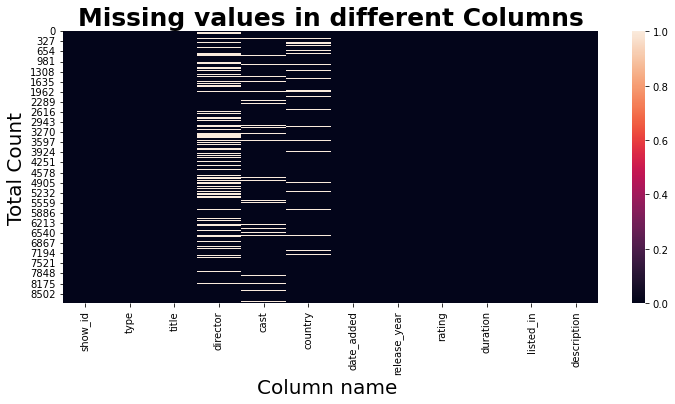

```python
missing_values=df.isna()

plt.figure( figsize = (12 , 5))
sns.heatmap(missing_values)
plt.title('Missing values in different Columns', size='25', fontweight="bold")
plt.xlabel("Column name ",fontsize=20)
plt.ylabel("Total Count",fontsize=20);
```

- **Among the columns director, cast and country, the most missing values are found.**

### 2.5 Dropping Nan values from Date_added, duration and rating.

```python
df.shape
```

```
(8807, 12)
```

```python
df[df['date_added'].isna()].shape
```

```
(10, 12)
```

```python
df[df['rating'].isna()].shape
```

```
(4, 12)
```

```python
df[df['duration'].isna()].shape
```

```
(3, 12)
```

**There are only 17 observations which are containing NaN values in date_added, rating and duration column.**

```python
df.dropna(subset=["date_added","rating","duration"],inplace=True)
```

```python
df.shape
```

```
(8790, 12)
```

**Before dropping the NaN values from "date_added","rating" and "duration" the shape was (8807,12)**  
**After dropping the NaN values from "date_added","rating" and "duration" the shape was (8790,12)**

### 2.6 Handling Nan values from Cast, director and country columns

```python
df["cast"]=df["cast"].astype(object).fillna("Unknown Actor")
df["country"]=df["country"].astype(object).fillna("Unknown country")
df["director"]=df["director"].astype(object).fillna("Unknown director")
df.head(10)
```

|  | show_id | type | title | director | cast | country | date_added | release_year | rating | duration | listed_in | description |
| --- | --- | --- | --- | --- | --- | --- | --- | --- | --- | --- | --- | --- |
| 0 | s1 | Movie | Dick Johnson Is Dead | Kirsten Johnson | Unknown Actor | United States | 2021-09-25 | 2020 | PG-13 | 90 min | Documentaries | As her father nears the end of his life, filmm... |
| 1 | s2 | TV Show | Blood & Water | Unknown director | Ama Qamata, Khosi Ngema, Gail Mabalane, Thaban... | South Africa | 2021-09-24 | 2021 | TV-MA | 2 Seasons | International TV Shows, TV Dramas, TV Mysteries | After crossing paths at a party, a Cape Town t... |
| 2 | s3 | TV Show | Ganglands | Julien Leclercq | Sami Bouajila, Tracy Gotoas, Samuel Jouy, Nabi... | Unknown country | 2021-09-24 | 2021 | TV-MA | 1 Season | Crime TV Shows, International TV Shows, TV Act... | To protect his family from a powerful drug lor... |
| 3 | s4 | TV Show | Jailbirds New Orleans | Unknown director | Unknown Actor | Unknown country | 2021-09-24 | 2021 | TV-MA | 1 Season | Docuseries, Reality TV | Feuds, flirtations and toilet talk go down amo... |
| 4 | s5 | TV Show | Kota Factory | Unknown director | Mayur More, Jitendra Kumar, Ranjan Raj, Alam K... | India | 2021-09-24 | 2021 | TV-MA | 2 Seasons | International TV Shows, Romantic TV Shows, TV ... | In a city of coaching centers known to train I... |
| 5 | s6 | TV Show | Midnight Mass | Mike Flanagan | Kate Siegel, Zach Gilford, Hamish Linklater, H... | Unknown country | 2021-09-24 | 2021 | TV-MA | 1 Season | TV Dramas, TV Horror, TV Mysteries | The arrival of a charismatic young priest brin... |
| 6 | s7 | Movie | My Little Pony: A New Generation | Robert Cullen, José Luis Ucha | Vanessa Hudgens, Kimiko Glenn, James Marsden, ... | Unknown country | 2021-09-24 | 2021 | PG | 91 min | Children & Family Movies | Equestria's divided. But a bright-eyed hero be... |
| 7 | s8 | Movie | Sankofa | Haile Gerima | Kofi Ghanaba, Oyafunmike Ogunlano, Alexandra D... | United States, Ghana, Burkina Faso, United Kin... | 2021-09-24 | 1993 | TV-MA | 125 min | Dramas, Independent Movies, International Movies | On a photo shoot in Ghana, an American model s... |
| 8 | s9 | TV Show | The Great British Baking Show | Andy Devonshire | Mel Giedroyc, Sue Perkins, Mary Berry, Paul Ho... | United Kingdom | 2021-09-24 | 2021 | TV-14 | 9 Seasons | British TV Shows, Reality TV | A talented batch of amateur bakers face off in... |
| 9 | s10 | Movie | The Starling | Theodore Melfi | Melissa McCarthy, Chris O'Dowd, Kevin Kline, T... | United States | 2021-09-24 | 2021 | PG-13 | 104 min | Comedies, Dramas | A woman adjusting to life after a loss contend... |

```python
df.isnull().sum()
```

```
show_id         0
type            0
title           0
director        0
cast            0
country         0
date_added      0
release_year    0
rating          0
duration        0
listed_in       0
description     0
dtype: int64
```

```python
df.shape
```

```
(8790, 12)
```

- After Handling and cleaning no observations which are containing NaN values in Dataframe
- <0.2% observations have been lost after cleaning the data.

## Adding two cloumns day_of_week and month

```python
df["Month"]=df["date_added"].dt.month_name()
df["day_of_week"]=df["date_added"].dt.day_name()
df["day_of_month"]=df["date_added"].dt.day
df.head()
```

|  | show_id | type | title | director | cast | country | date_added | release_year | rating | duration | listed_in | description | Month | day_of_week | day_of_month |
| --- | --- | --- | --- | --- | --- | --- | --- | --- | --- | --- | --- | --- | --- | --- | --- |
| 0 | s1 | Movie | Dick Johnson Is Dead | Kirsten Johnson | Unknown Actor | United States | 2021-09-25 | 2020 | PG-13 | 90 min | Documentaries | As her father nears the end of his life, filmm... | September | Saturday | 25 |
| 1 | s2 | TV Show | Blood & Water | Unknown director | Ama Qamata, Khosi Ngema, Gail Mabalane, Thaban... | South Africa | 2021-09-24 | 2021 | TV-MA | 2 Seasons | International TV Shows, TV Dramas, TV Mysteries | After crossing paths at a party, a Cape Town t... | September | Friday | 24 |
| 2 | s3 | TV Show | Ganglands | Julien Leclercq | Sami Bouajila, Tracy Gotoas, Samuel Jouy, Nabi... | Unknown country | 2021-09-24 | 2021 | TV-MA | 1 Season | Crime TV Shows, International TV Shows, TV Act... | To protect his family from a powerful drug lor... | September | Friday | 24 |
| 3 | s4 | TV Show | Jailbirds New Orleans | Unknown director | Unknown Actor | Unknown country | 2021-09-24 | 2021 | TV-MA | 1 Season | Docuseries, Reality TV | Feuds, flirtations and toilet talk go down amo... | September | Friday | 24 |
| 4 | s5 | TV Show | Kota Factory | Unknown director | Mayur More, Jitendra Kumar, Ranjan Raj, Alam K... | India | 2021-09-24 | 2021 | TV-MA | 2 Seasons | International TV Shows, Romantic TV Shows, TV ... | In a city of coaching centers known to train I... | September | Friday | 24 |

### category dtype

```python
df["type"]=df["type"].astype("category")
```

```python
df["rating"]=df["rating"].astype("category")
```

```python
df.info()
```

```
<class 'pandas.core.frame.DataFrame'>
Int64Index: 8790 entries, 0 to 8806
Data columns (total 15 columns):
 #   Column        Non-Null Count  Dtype
---  ------        --------------  -----
 0   show_id       8790 non-null   object
 1   type          8790 non-null   category
 2   title         8790 non-null   object
 3   director      8790 non-null   object
 4   cast          8790 non-null   object
 5   country       8790 non-null   object
 6   date_added    8790 non-null   datetime64[ns]
 7   release_year  8790 non-null   int64
 8   rating        8790 non-null   category
 9   duration      8790 non-null   object
 10  listed_in     8790 non-null   object
 11  description   8790 non-null   object
 12  Month         8790 non-null   object
 13  day_of_week   8790 non-null   object
 14  day_of_month  8790 non-null   int64
dtypes: category(2), datetime64[ns](1), int64(2), object(10)
memory usage: 979.3+ KB
```

## 4 Unnesting the nesting columns

### 3.1 unnesting the "cast" column

```python
df_Actor_data = df.set_index('title').cast.str.split(', ', expand=True).stack().reset_index(level=1,drop=True)
df_Actor_data=df_Actor_data.reset_index(name="Actor")
df_Actor_data.head()
```

|  | title | Actor |
| --- | --- | --- |
| 0 | Dick Johnson Is Dead | Unknown Actor |
| 1 | Blood & Water | Ama Qamata |
| 2 | Blood & Water | Khosi Ngema |
| 3 | Blood & Water | Gail Mabalane |
| 4 | Blood & Water | Thabang Molaba |

### 3.2 unnesting the "country" column

```python
df_country_data = df.set_index('title').country.str.split(', ', expand=True).stack().reset_index(level=1,drop=True)
df_country_data=df_country_data.reset_index(name="country")
df_country_data.head()
```

|  | title | country |
| --- | --- | --- |
| 0 | Dick Johnson Is Dead | United States |
| 1 | Blood & Water | South Africa |
| 2 | Ganglands | Unknown country |
| 3 | Jailbirds New Orleans | Unknown country |
| 4 | Kota Factory | India |

### 3.3 unnesting the "director" column

```python
df_director_data = df.set_index('title').director.str.split(', ', expand=True).stack().reset_index(level=1,drop=True)
df_director_data=df_director_data.reset_index(name="director")
df_director_data.head()
```

|  | title | director |
| --- | --- | --- |
| 0 | Dick Johnson Is Dead | Kirsten Johnson |
| 1 | Blood & Water | Unknown director |
| 2 | Ganglands | Julien Leclercq |
| 3 | Jailbirds New Orleans | Unknown director |
| 4 | Kota Factory | Unknown director |

### 3.4 unnesting the listed_in column

```python
df_Genre_data = df.set_index('title').listed_in.str.split(', ', expand=True).stack().reset_index(level=1,drop=True)
df_Genre_data=df_Genre_data.reset_index(name="Genre")
df_Genre_data.head()
```

|  | title | Genre |
| --- | --- | --- |
| 0 | Dick Johnson Is Dead | Documentaries |
| 1 | Blood & Water | International TV Shows |
| 2 | Blood & Water | TV Dramas |
| 3 | Blood & Water | TV Mysteries |
| 4 | Ganglands | Crime TV Shows |

## 4 Merging Unnested Columns with Main DataFrame and to get new dataFrame

```python
# merging the unnested cast data with unnested country data:
df2=df_Actor_data.merge(df_country_data,on=["title"])
# merging the unnested director data with df2 data
df3=df_director_data.merge(df2,on=["title"])
# merging the unnested listed_in data with df3 data
df_new=df_Genre_data.merge(df3,on=["title"])
df_new
```

|  | title | Genre | director | Actor | country |
| --- | --- | --- | --- | --- | --- |
| 0 | Dick Johnson Is Dead | Documentaries | Kirsten Johnson | Unknown Actor | United States |
| 1 | Blood & Water | International TV Shows | Unknown director | Ama Qamata | South Africa |
| 2 | Blood & Water | International TV Shows | Unknown director | Khosi Ngema | South Africa |
| 3 | Blood & Water | International TV Shows | Unknown director | Gail Mabalane | South Africa |
| 4 | Blood & Water | International TV Shows | Unknown director | Thabang Molaba | South Africa |
| ... | ... | ... | ... | ... | ... |
| 201758 | Zubaan | Music & Musicals | Mozez Singh | Manish Chaudhary | India |
| 201759 | Zubaan | Music & Musicals | Mozez Singh | Meghna Malik | India |
| 201760 | Zubaan | Music & Musicals | Mozez Singh | Malkeet Rauni | India |
| 201761 | Zubaan | Music & Musicals | Mozez Singh | Anita Shabdish | India |
| 201762 | Zubaan | Music & Musicals | Mozez Singh | Chittaranjan Tripathy | India |

201763 rows × 5 columns

```python
# final Netflix DataFrame after merging with df_new
```

```python
df_netflix=df_new.merge(df[["show_id","type","title","date_added","release_year","Month","day_of_week","rating","duration","day_of_month"]],on=["title"],how="left")
df_netflix
```

|  | title | Genre | director | Actor | country | show_id | type | date_added | release_year | Month | day_of_week | rating | duration | day_of_month |
| --- | --- | --- | --- | --- | --- | --- | --- | --- | --- | --- | --- | --- | --- | --- |
| 0 | Dick Johnson Is Dead | Documentaries | Kirsten Johnson | Unknown Actor | United States | s1 | Movie | 2021-09-25 | 2020 | September | Saturday | PG-13 | 90 min | 25 |
| 1 | Blood & Water | International TV Shows | Unknown director | Ama Qamata | South Africa | s2 | TV Show | 2021-09-24 | 2021 | September | Friday | TV-MA | 2 Seasons | 24 |
| 2 | Blood & Water | International TV Shows | Unknown director | Khosi Ngema | South Africa | s2 | TV Show | 2021-09-24 | 2021 | September | Friday | TV-MA | 2 Seasons | 24 |
| 3 | Blood & Water | International TV Shows | Unknown director | Gail Mabalane | South Africa | s2 | TV Show | 2021-09-24 | 2021 | September | Friday | TV-MA | 2 Seasons | 24 |
| 4 | Blood & Water | International TV Shows | Unknown director | Thabang Molaba | South Africa | s2 | TV Show | 2021-09-24 | 2021 | September | Friday | TV-MA | 2 Seasons | 24 |
| ... | ... | ... | ... | ... | ... | ... | ... | ... | ... | ... | ... | ... | ... | ... |
| 201758 | Zubaan | Music & Musicals | Mozez Singh | Manish Chaudhary | India | s8807 | Movie | 2019-03-02 | 2015 | March | Saturday | TV-14 | 111 min | 2 |
| 201759 | Zubaan | Music & Musicals | Mozez Singh | Meghna Malik | India | s8807 | Movie | 2019-03-02 | 2015 | March | Saturday | TV-14 | 111 min | 2 |
| 201760 | Zubaan | Music & Musicals | Mozez Singh | Malkeet Rauni | India | s8807 | Movie | 2019-03-02 | 2015 | March | Saturday | TV-14 | 111 min | 2 |
| 201761 | Zubaan | Music & Musicals | Mozez Singh | Anita Shabdish | India | s8807 | Movie | 2019-03-02 | 2015 | March | Saturday | TV-14 | 111 min | 2 |
| 201762 | Zubaan | Music & Musicals | Mozez Singh | Chittaranjan Tripathy | India | s8807 | Movie | 2019-03-02 | 2015 | March | Saturday | TV-14 | 111 min | 2 |

201763 rows × 14 columns

```python
df_netflix.isnull().sum()
```

```
title           0
Genre           0
director        0
Actor           0
country         0
show_id         0
type            0
date_added      0
release_year    0
Month           0
day_of_week     0
rating          0
duration        0
day_of_month    0
dtype: int64
```

## 5 value count and nunique

### 5.1 Value Count

```python
# Value Count of type (Movie and TV Show)

df_netflix.groupby("type").agg({"title":"nunique"})
```

| type | title |
| --- | --- |
| Movie | 6126 |
| TV Show | 2664 |

- Netflix has 6126 movies and 2664 TV shows out of 8790 types of content.

```python
# value count of Genre

df_netflix.groupby("Genre").agg({"title":"nunique"}).sort_values(by="title",ascending=False).head(5)
```

| Genre | title |
| --- | --- |
| International Movies | 2752 |
| Dramas | 2426 |
| Comedies | 1674 |
| International TV Shows | 1349 |
| Documentaries | 869 |

- The content on Netflix consists mostly of international movies, dramas, and comedies.

```python
# country wise contents value counts

df_netflix.groupby("country").agg({"title":"nunique"}).sort_values(by="title",ascending=False).head(2)
```

| country | title |
| --- | --- |
| United States | 3680 |
| India | 1046 |

- The majority of Netflix's content is targeted at Americans and Indians.

### 5.2 nunique

```python
# unique
df_netflix.nunique()
```

```
title            8790
Genre              42
director         4992
Actor           36393
country           128
show_id          8790
type                2
date_added       1713
release_year       74
Month              12
day_of_week         7
rating             14
duration          220
day_of_month       31
dtype: int64
```

- **A total of 8790 contents are available on Netflix, which includes two types of content - movies and television shows.**
- **There are 4992 directors who direct different types of movies and television shows.**
- **There are 42 genres of content available on Netflix and it is available in 128 countries.**

## Exploratory Analysis and Visualization

```python
df.head()
```

|  | show_id | type | title | director | cast | country | date_added | release_year | rating | duration | listed_in | description | Month | day_of_week | day_of_month |
| --- | --- | --- | --- | --- | --- | --- | --- | --- | --- | --- | --- | --- | --- | --- | --- |
| 0 | s1 | Movie | Dick Johnson Is Dead | Kirsten Johnson | Unknown Actor | United States | 2021-09-25 | 2020 | PG-13 | 90 min | Documentaries | As her father nears the end of his life, filmm... | September | Saturday | 25 |
| 1 | s2 | TV Show | Blood & Water | Unknown director | Ama Qamata, Khosi Ngema, Gail Mabalane, Thaban... | South Africa | 2021-09-24 | 2021 | TV-MA | 2 Seasons | International TV Shows, TV Dramas, TV Mysteries | After crossing paths at a party, a Cape Town t... | September | Friday | 24 |
| 2 | s3 | TV Show | Ganglands | Julien Leclercq | Sami Bouajila, Tracy Gotoas, Samuel Jouy, Nabi... | Unknown country | 2021-09-24 | 2021 | TV-MA | 1 Season | Crime TV Shows, International TV Shows, TV Act... | To protect his family from a powerful drug lor... | September | Friday | 24 |
| 3 | s4 | TV Show | Jailbirds New Orleans | Unknown director | Unknown Actor | Unknown country | 2021-09-24 | 2021 | TV-MA | 1 Season | Docuseries, Reality TV | Feuds, flirtations and toilet talk go down amo... | September | Friday | 24 |
| 4 | s5 | TV Show | Kota Factory | Unknown director | Mayur More, Jitendra Kumar, Ranjan Raj, Alam K... | India | 2021-09-24 | 2021 | TV-MA | 2 Seasons | International TV Shows, Romantic TV Shows, TV ... | In a city of coaching centers known to train I... | September | Friday | 24 |

## Last 20 Year movies released:

```python
df_movie=df[df["type"]=="Movie"][["title","release_year"]]
df_movie_last_20=df_movie[df_movie["release_year"]>=2001].sort_values(by="release_year")
```

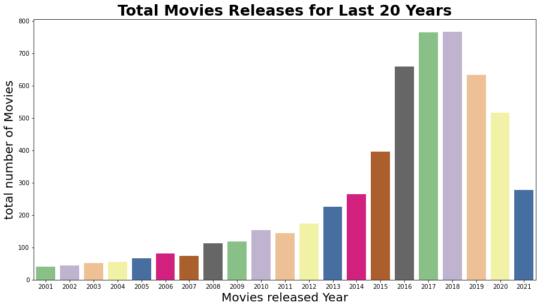

```python
plt.figure(figsize=(15,8))
sns.countplot(x='release_year',data=df_movie_last_20,palette="Accent")
plt.title('Total Movies Releases for Last 20 Years', size='25', fontweight="bold")
plt.xlabel("Movies released Year",fontsize=20)
plt.ylabel("total number of Movies",fontsize=20)
plt.show()
```

**The number of movies release have significantly increasing from last 20 years but have dropped in 2019 onwards because of Covid 19**

### Duration of the movies - (Distplot)

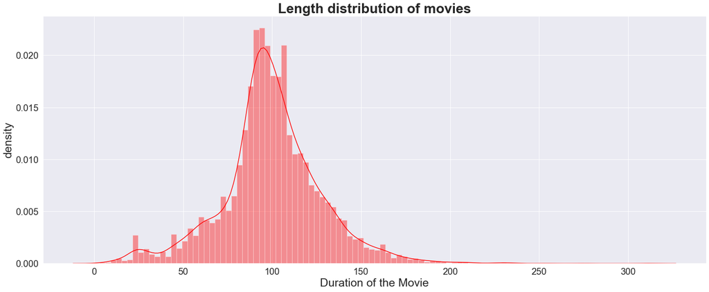

```python
movie_duration=df[df["type"]=="Movie"]["duration"].str.split(" ", expand= True)[0].astype(float)

sns.set(style="darkgrid")
plt.figure(figsize=(26,10), facecolor="white")
sns.distplot(movie_duration,color ="red",bins=100)
plt.xlabel("Duration of the Movie",fontsize=25)
plt.ylabel("density",fontsize=25)
plt.xticks(fontsize= 20 )
plt.yticks(fontsize= 20 )
plt.title('Length distribution of movies',size=30,fontweight="bold")
plt.show()
```

- **It is estimated that almost 64% of movies have a runtime between 80 minutes to 120 minutes.**

## Content Release in Week -(Histplot)

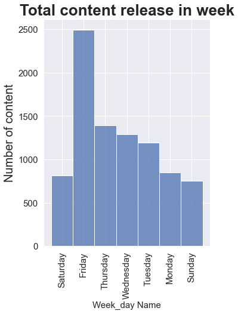

```python
plt.figure(figsize=(5,7))
sns.histplot(df["day_of_week"])
plt.title("Total content release in week",size=26,fontweight="bold")
plt.ylabel("Number of content",fontsize=20)
plt.xlabel("Week_day Name",fontsize=15)
plt.yticks(fontsize=15)
plt.xticks(fontsize=15,rotation=90)
plt.show()
```

**We can see from the graph that most movies and television shows are released on Friday**

## Movies vs TV-shows

### Content type on Netflix

```python
df_movie=df[df["type"]=="Movie"]
df_tv_shows=df[df["type"]=="TV Show"]
#movie_per=round((len(df_movie)/(len(df))*100),2)
#tvshow_per=round((len(df_tv_shows)/(len(df))*100),2)
```

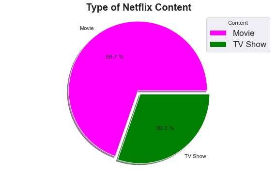

```python
plt.figure(figsize=(10,6), facecolor="white")
plt.pie([len(df_movie),len(df_tv_shows)],labels=["Movie","TV Show"], autopct ='% 1.1f %%',explode=[0.03,0.03],shadow=True,colors=["magenta","green"])
plt.title('Type of Netflix Content', fontsize=20,fontweight="bold");
plt.axis("equal")
plt.xticks(fontsize= 20 )
plt.yticks(fontsize= 20 )
plt.legend(title="Content",fontsize=17)
plt.show()
```

- **69.7% of the content available on Netflix are movies; the remaining 30.3% are TV Shows.**

### Content growth over the year.

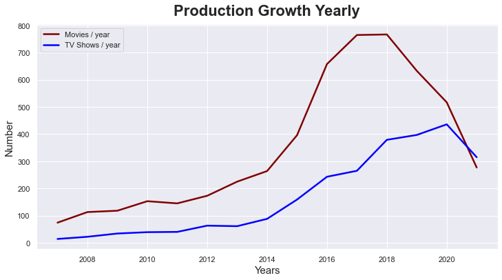

```python
yearly_shows=df[df.type =='TV Show']['release_year'].value_counts().sort_index(ascending=False).head(15)
yearly_movies=df[df.type =='Movie']['release_year'].value_counts().sort_index(ascending=False).head(15)

yearly_movies.plot(figsize=(12, 6), linewidth=2.5, color='maroon',label="Movies / year",ms=3)
yearly_shows.plot(figsize=(12, 6), linewidth=2.5, color='blue',label="TV Shows / year")
plt.xlabel("Years", fontsize=15)
plt.ylabel("Number", fontsize=15)
plt.legend(loc="upper left")
plt.title("Production Growth Yearly", y=1.02, fontsize=22,fontweight="bold");
```

## Best time to launch a TV show

```python
months_df = pd.DataFrame(df[df.type =='TV Show']['Month'].value_counts())
months_df.reset_index(inplace=True)
months_df.rename(columns={"index":"month","Month":'count'}, inplace=True)
```

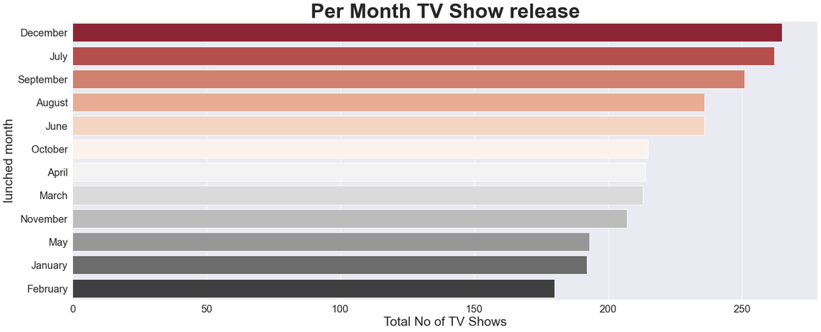

```python
sns.set(style="darkgrid")
plt.figure(figsize=(26,10), facecolor="white")
sns.barplot(data=months_df, y="month", x="count",palette="RdGy")
plt.xlabel("Total No of TV Shows",fontsize=25)
plt.ylabel("lunched month",fontsize=25)
plt.xticks(fontsize= 20 )
plt.yticks(fontsize= 20 )
plt.title('Per Month TV Show release', fontsize=40,fontweight="bold");
plt.show()
```

- **There is no better time to release TV shows than December, since it is Christmas month and the holiday season.**

```python
df_day_release= df_netflix.groupby(["day_of_month","type"]).agg({"title":"nunique"}).reset_index().sort_values(by="title",ascending=False)
```

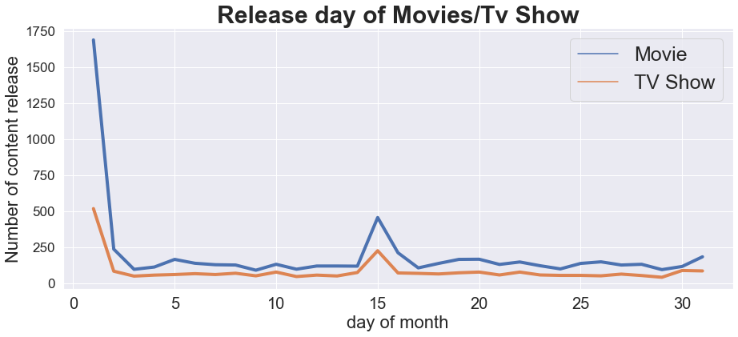

```python
sns.set(style="darkgrid")
plt.figure(figsize=(15,6))
sns.lineplot(data=df_day_release, x="day_of_month", y="title",hue="type",ci=None,linewidth=4)
plt.xlabel( "day of month",fontsize=22)
plt.ylabel("Number of content release",fontsize=22)
plt.xticks(fontsize= 20 )
plt.yticks(fontsize= 17 )
plt.title('Release day of Movies/Tv Show', fontsize=30,fontweight="bold")
plt.legend(fontsize=25)
plt.show()
```

- **The first day of the month is the release date of almost 25% of movies and television shows.**
- **15th day of the month is second favorite date to release movies and television shows.**